# Titanic Prediction Notes

Jia Liu

October 6, 2014

## Abstract

In this document, we explore the performance of various statistical/machine learning algorithm on Titanic data from [kaggle](https://www.kaggle.com/c/titanic-gettingStarted/data).

## Explore data

Firstly we need to load some functions to let the data manipulation easier.

```r
library(data.table)
library(dplyr)
library(ggplot2)
library(gmodels) # for 2-way cross tabulation
```

Then we read in test data and explorer the possible connection between features of the passenger and their destiny.

```r
titanic_train_data = fread("data/train.csv", na.strings="") # read as data.table
```

Then we take a quick look at the head of this data, see what is it like:

```
##    PassengerId Survived Pclass
## 1:           1        0      3
## 2:           2        1      1
## 3:           3        1      3
## 4:           4        1      1
## 5:           5        0      3
## 6:           6        0      3
##                                                   Name    Sex Age SibSp
## 1:                             Braund, Mr. Owen Harris   male  22     1
## 2: Cumings, Mrs. John Bradley (Florence Briggs Thayer) female  38     1
## 3:                              Heikkinen, Miss. Laina female  26     0
## 4:        Futrelle, Mrs. Jacques Heath (Lily May Peel) female  35     1
## 5:                            Allen, Mr. William Henry   male  35     0
## 6:                                    Moran, Mr. James   male  NA     0
##    Parch           Ticket   Fare Cabin Embarked
## 1:     0        A/5 21171  7.250              S
## 2:     0         PC 17599 71.283   C85        C
## 3:     0 STON/O2. 3101282  7.925              S
## 4:     0           113803 53.100  C123        S
## 5:     0           373450  8.050              S
## 6:     0           330877  8.458              Q
```

So we have **PassengerId, Survived, Pclass, Name, Sex, Age, SibSp, Parch, Ticket, Fare, Cabin, Embarked** in the data set. **Survived** is what we need to predict, others are the features of each passenger. Kaggle gives explanation about the meaning of each feature:

> survival: Survival (0 = No; 1 = Yes)  
> pclass : Passenger Class (1 = 1st; 2 = 2nd; 3 = 3rd)  
> name : Name  
> sex : Sex  
> age : Age  
> sibsp : Number of Siblings/Spouses Aboard  
> parch : Number of Parents/Children Aboard  
> ticket : Ticket Number  
> fare : Passenger Fare  
> cabin : Cabin  
> embarked: Port of Embarkation  
> (C = Cherbourg; Q = Queenstown; S = Southampton)

From all these features, name is unimportant. In other features, we would guess “pclass”, “sex”, and “age” are strong indicators of survival: higher class may have priviledge to board the lifeboat; younger people has higher chance to run to the lifeboat; and here is an old rule for boarding priority: “women and children first”. So let’s see if this is the case:

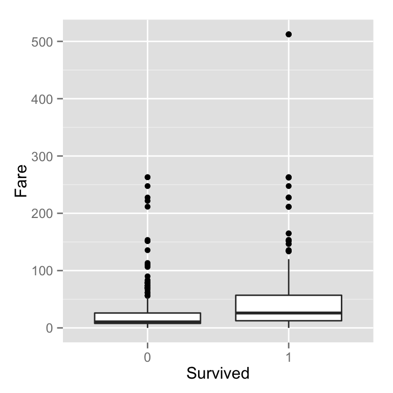

```r
# higher fare survives?
ggplot(titanic_train_data, aes(factor(Survived), Fare))+
  geom_boxplot()+xlab("Survived")
```

```r
# higher class survives?
with(titanic_train_data, prop.table(table(Pclass, Survived)))
```

```
##       Survived
## Pclass       0       1
##      1 0.08979 0.15264
##      2 0.10887 0.09764
##      3 0.41751 0.13356
```

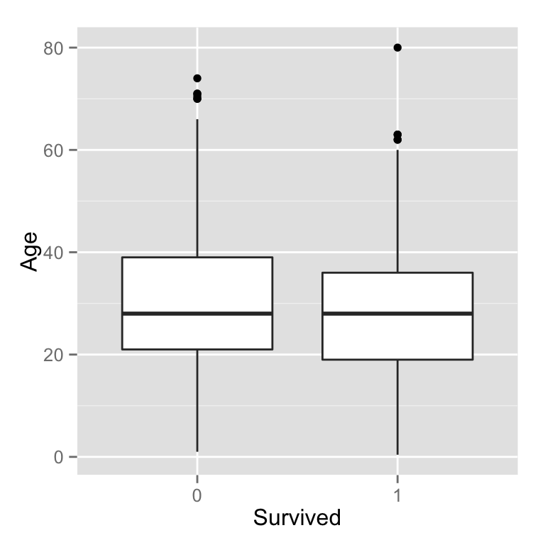

```r
# younger people survives?
ggplot(titanic_train_data, aes(factor(Survived), Age))+
  geom_boxplot()+xlab("Survived")
```

```r
# female survives?
with(titanic_train_data, prop.table(table(Sex, Survived)))
```

```
##         Survived
## Sex            0       1
##   female 0.09091 0.26150
##   male   0.52525 0.12233
```

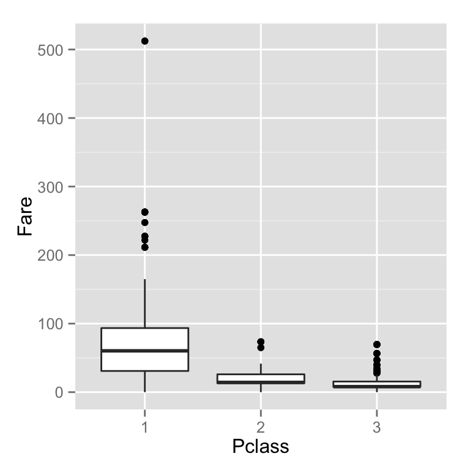

```r
# higher fare associates with higher pclass
ggplot(titanic_train_data, aes(factor(Pclass), Fare))+
  geom_boxplot()+xlab("Pclass")
```

From above tables and plot, we clearly see that:  
- People pays higher fare has higher survival chance;  
- People at higher class has higher chance to survive;  
- Age seems like not a good indicator for survival;  
- Women has much higher survival rates than men;  
- Fare associates with Pclass.

Two big questions remains:  
1. Does the Age~Survived plot really trustable, even it contains lots of missing data ( 177 out of 891 rows)?  
2. Other features are not important at all? From guts feeling, they are not.

To answer these two question, we need to use statistical hypothesis test, if we accept all the underlying distributions coming with these test. If we forgo these questions, we would better chose any algorithm containing regularization, to include these features while deal with possible overfitting. There are other problems we have to address: are `Fare` and `Pclass` highly correlated, is there any interaction between features?

Before implementing any learning algorithem to this data, we have to clean them at first, realizing there are some nomial features, and `Age` information is highly incomplete.

## Clean the data

### Categorical/Nomial data:

There are several nomial features, let’s convert them to `factor` while keeping their original values explicitly (otherwise R will use other `levels` to substitute these values):

```r
titanic_train_data$Survived = factor(titanic_train_data$Survived,
                                        levels=c(0, 1),
                                        labels=c("0","1"))
titanic_train_data$Pclass   = factor(titanic_train_data$Pclass,
                                        levels=c(1, 2, 3),
                                        labels=c("1","2","3"))
titanic_train_data$Sex      = factor(titanic_train_data$Sex,
                                     levels=c("female", "male"),
                                     labels=c("0", "1"))# for easy interpretation
titanic_train_data$Embarked = as.factor(titanic_train_data$Embarked)
```

#### *Aside: Naive logistic regression test*

Let’s press for a little bit, see what will come out if we do a “naive” logistic regression on the train data. Saying naive, I mean we only look at the complete cases (case with no missing value), and the interaction between features are simply ignored. The purpose of this test is to see how the features associate with the outcome.

```
##
## Call:
## glm(formula = Survived ~ Pclass + Sex + Age + SibSp + Parch +
##     Fare, family = "binomial", data = titanic_train_complete)
##
## Deviance Residuals:
##    Min      1Q  Median      3Q     Max
## -2.801  -0.639  -0.386   0.634   2.442
##
## Coefficients:
##             Estimate Std. Error z value Pr(>|z|)
## (Intercept)  4.17999    0.50342    8.30  < 2e-16 ***
## Pclass2     -1.29254    0.32176   -4.02  5.9e-05 ***
## Pclass3     -2.50107    0.33874   -7.38  1.5e-13 ***
## Sex1        -2.63745    0.22008  -11.98  < 2e-16 ***
## Age         -0.04416    0.00826   -5.34  9.1e-08 ***
## SibSp       -0.37685    0.12748   -2.96   0.0031 **
## Parch       -0.06127    0.12293   -0.50   0.6182
## Fare         0.00204    0.00256    0.80   0.4254
## ---
## Signif. codes:  0 '***' 0.001 '**' 0.01 '*' 0.05 '.' 0.1 ' ' 1
##
## (Dispersion parameter for binomial family taken to be 1)
##
##     Null deviance: 964.52  on 713  degrees of freedom
## Residual deviance: 635.78  on 706  degrees of freedom
## AIC: 651.8
##
## Number of Fisher Scoring iterations: 5
```

From the wald test given by the summary, we see **Pclass, Sex, Age, SibSp** are statistically significant in predicting survival, but how well this naive logistic model performes?

```r
titanic_naive_logit_prediction = predict(titanic_naive_logit, type="response")
titanic_naive_logit_prediction[titanic_naive_logit_prediction>0.5]=1
titanic_naive_logit_prediction[titanic_naive_logit_prediction<=0.5]=0
temp_table=table(pred=titanic_naive_logit_prediction, truth=titanic_train_complete$Survived)
ftable(temp_table)
```

```
##      truth   0   1
## pred
## 0          364  79
## 1           60 211
```

So there are 139 out of 714 misclassified, or 80.5322% passenger has been correctly classified.

This is not bad. But we see the effect of `Age` is significant, eventually we need the information of `Age` to make more stronger prediction. This means we need to impute `Age` seriously. We introduce the interaction between `Age` and `Sex`, and `Age` and `Pclass`, because there is a saying in kaggle that younger nobel women has very high survival rate.

```
##      truth   0   1
## pred
## 0          379  57
## 1           45 233
```

The fate of 85.7143% passenger has been correctly classified, it is quite a bit improvement. But in this model, `glm` does not converge. We can try to use penalized glm to avoid this. Before digging deeper, let’s see how does this naive logistic regression model perform at prediction:

```r
titanic_test_data=fread("data/test.csv", na.strings="")
# clean the data
titanic_test_data$Pclass = factor(titanic_test_data$Pclass,
                                        levels=c(1, 2, 3),
                                        labels=c("1","2","3"))
titanic_test_data$Sex = factor(titanic_test_data$Sex,
                                     levels=c("female", "male"),
                                     labels=c("0", "1"))# for easy interpretation
titanic_test_data_original = titanic_test_data
# fill missing age with mean age
titanic_test_data$Age[is.na(titanic_test_data$Age)]=mean(titanic_test_data$Age, na.rm=T)
titanic_test_data$Fare[is.na(titanic_test_data$Fare)]=mean(titanic_test_data$Fare, na.rm=T)
# fill in interaction
titanic_pred = predict(titanic_naive_logit,
                                  newdata = titanic_test_data,
                                  type="response")
titanic_pred[titanic_pred<0.5]=0
titanic_pred[titanic_pred>=0.5]=1
titanic_test_data$Survived = titanic_pred
write.csv(select(titanic_test_data, PassengerId, Survived),
          file="prediction.csv",
          row.names=FALSE)
```

Well, kaggle gives **0.75120**, not good at all.

### Imputate data

We are left with many NAs in this data set, let’s see how many in them:

```
## PassengerId    Survived      Pclass        Name         Sex         Age
##           0           0           0           0           0         177
##       SibSp       Parch      Ticket        Fare       Cabin    Embarked
##           0           0           0           0           0           0
```

We have lost so much information in `Age`. I don’t want to build my model on a wobbling brick, so I need to find a plausible way to imputate `Age`.

I’ll use R package `Amelia II` to do the imputation. This method requires multivariate normality and the missing at random assumption. These are satisfied in most cases.

Besides, `Amelia` requires all information to be put into it, while eliminating factor input.

```r
library(Amelia)
a.out = amelia(titanic_train_data, m=5,
               idvars = c(2, 3, 4, 5, 9,11,12)) # exclude factors, make 5 imputed datasets
```

```
## -- Imputation 1 --
##
##   1  2  3
##
## -- Imputation 2 --
##
##   1  2  3
##
## -- Imputation 3 --
##
##   1  2  3
##
## -- Imputation 4 --
##
##   1  2  3
##
## -- Imputation 5 --
##
##   1  2  3
```

```r
library(plyr)
train_data_ameliaed = ldply(a.out$imputations) # combine all imputed datasets
#train_data_ameliaed = a.out$imputations[[5]] # only use one imputed dataset
# train all the data
train_data_ameliaed_logit = glm(Survived~Pclass+Sex+Age+SibSp+Parch+Fare,
                          data=train_data_ameliaed,
                          family="binomial")
train_data_ameliaed_pred = predict(train_data_ameliaed_logit, type="response")
train_data_ameliaed_pred[train_data_ameliaed_pred<0.5]=0
train_data_ameliaed_pred[train_data_ameliaed_pred>=0.5]=1
temp_table = table(pred = train_data_ameliaed_pred, truth=train_data_ameliaed$Survived)
prop.table(temp_table)
```

```
##     truth
## pred       0       1
##    0 0.53603 0.11785
##    1 0.08013 0.26599
```

We have 80.202% correctness.

If we do not use `Amelia`, but use the “naive” model (missing ages equal to mean age), to impute missing data, what would happen? Imputing data by the mean can cause the result biased. For example, if younger people has higher chance to escape, imputing missing age by mean age would increase (low mean age) or decrease the survival rate for the people without age information. Let’s see what will happen under this naive imputation method.

```r
titanic_train_data_naiveImpute = titanic_train_data
titanic_train_data_naiveImpute$Age[is.na(titanic_train_data_naiveImpute$Age)]=
  mean(titanic_train_data_naiveImpute$Age,na.rm=T)
train_data_logit_naiveImpute = glm(Survived~Pclass+Sex+Age+SibSp+Parch+Fare,
                          data=titanic_train_data_naiveImpute,
                          family="binomial")
train_data_naiveImpute_pred = predict(train_data_logit_naiveImpute,
                                            type="response")
train_data_naiveImpute_pred[train_data_naiveImpute_pred<0.5]=0
train_data_naiveImpute_pred[train_data_naiveImpute_pred>=0.5]=1
temp_table = table(pred = train_data_naiveImpute_pred,
                   truth=titanic_train_data_naiveImpute$Survived)
prop.table(temp_table)
```

```
##     truth
## pred       0       1
##    0 0.52974 0.11560
##    1 0.08642 0.26824
```

This naive imputation gives 79.798% correct classification, a little lower than the `Amelia` result. Let’s see how `Amelia` helps to improve the kaggle score.

```r
test_data_length=nrow(titanic_test_data_original)
titanic_test_data_2 = titanic_test_data_original
a.out2 = amelia(titanic_test_data_original, m=5, idvars=c(2, 3,4, 8, 10, 11))
```

```
## -- Imputation 1 --
##
##   1  2  3  4
##
## -- Imputation 2 --
##
##   1  2  3  4  5
##
## -- Imputation 3 --
##
##   1  2  3  4  5  6  7  8  9
##
## -- Imputation 4 --
##
##   1  2  3  4  5  6
##
## -- Imputation 5 --
##
##   1  2  3  4  5  6
```

```r
titanic_test_ameliaed = ldply(a.out2$imputations)
# make prediction
titanic_pred_5sets = predict(train_data_logit_naiveImpute,
                                  newdata = titanic_test_ameliaed,
                                  type="response")
titanic_pred_5sets[titanic_pred_5sets<0.5]=0
titanic_pred_5sets[titanic_pred_5sets>=0.5]=1
# since we used 5 imputed datasets, need to summarise to one final output
idx_temp = rep(seq(1,test_data_length), 5)
titanic_pred_dt = data.table(idx=idx_temp, pred=titanic_pred_5sets)
titanic_pred = titanic_pred_dt[,lapply(.SD, sum), .SDcol="pred", by="idx"]
titanic_pred = titanic_pred$pred
titanic_pred[titanic_pred<=2]=0
titanic_pred[titanic_pred>2]=1 # majority vote
# write to file
titanic_test_data_2$Survived = titanic_pred
write.csv(select(titanic_test_data_2, PassengerId, Survived),
          file="prediction_amelia.csv",
          row.names=FALSE)
```

Kaggle gives **0.74163**, no much improvement after we implement `Amelia` to impute data.

## Model Building

### Support Vector Machine

Support vector machine with a liner kernel applies to the case when the number of records is large (n=4455) while the features is small (m=11), according to Andrew Ng’s *Machine Learning* course. The script please see ‘titanic_svm.R’. It implements the `Amelia` to impute data, and use the majority vote to predict the final result. This would give similar results as logistic regression. The implementation only gets 0.71770 from kaggle. Not good at all!

### Principle Component Analysis

In the previous section, we have seen that some variables are correlated. So we don’t really need all the variables. Doing a principle component analysis may help us to reduce the total number of parameters and avoid the inclusion of repetitive variables. First we select all the numerical type columns:

```r
titanic_ameliaed_numericFeatures = select(train_data_ameliaed,
                                        Pclass,Sex, Age,
                                        SibSp,Parch,Fare)
titanic_ameliaed_numericFeatures$Pclass =
  as.numeric(levels(titanic_ameliaed_numericFeatures$Pclass)[titanic_ameliaed_numericFeatures$Pclass])
titanic_ameliaed_numericFeatures$Sex =
  as.numeric(levels(titanic_ameliaed_numericFeatures$Sex)[titanic_ameliaed_numericFeatures$Sex])
titanic_ameliaed_outcome = select(train_data_ameliaed, Survived)
# show correlation and covariance matrix
train_corr = cor(titanic_ameliaed_numericFeatures)
print(train_corr)
```

```
##          Pclass      Sex      Age    SibSp    Parch     Fare
## Pclass  1.00000  0.13190 -0.31801  0.08308  0.01844 -0.54950
## Sex     0.13190  1.00000  0.08555 -0.11463 -0.24549 -0.18233
## Age    -0.31801  0.08555  1.00000 -0.35312 -0.21222  0.06902
## SibSp   0.08308 -0.11463 -0.35312  1.00000  0.41484  0.15965
## Parch   0.01844 -0.24549 -0.21222  0.41484  1.00000  0.21622
## Fare   -0.54950 -0.18233  0.06902  0.15965  0.21622  1.00000
```

```r
train_cov  = cov(titanic_ameliaed_numericFeatures)
print(train_cov)
```

```
##           Pclass      Sex      Age    SibSp    Parch     Fare
## Pclass   0.69839  0.05266  -3.8932  0.07653  0.01242  -22.810
## Sex      0.05266  0.22827   0.5988 -0.06037 -0.09450   -4.327
## Age     -3.89320  0.59877 214.6052 -5.70190 -2.50486   50.224
## SibSp    0.07653 -0.06037  -5.7019  1.21495  0.36841    8.741
## Parch    0.01242 -0.09450  -2.5049  0.36841  0.64914    8.653
## Fare   -22.80969 -4.32706  50.2243  8.74088  8.65327 2467.219
```

```r
# show standard deviation
train_sd = apply(titanic_ameliaed_numericFeatures, 2 ,sd)
print(train_sd)
```

```
##  Pclass     Sex     Age   SibSp   Parch    Fare
##  0.8357  0.4778 14.6494  1.1022  0.8057 49.6711
```

We observe that `Pclass` and `Fare` are negatively correlated, `Parch` and `SibSp` are positively correlated. Also we notice the variance is quite different. Then we perform the PCA using the correlation matrix:

```r
pca_train = princomp(titanic_ameliaed_numericFeatures, cor=T)
summary(pca_train)
```

```
## Importance of components:
##                        Comp.1 Comp.2 Comp.3 Comp.4  Comp.5  Comp.6
## Standard deviation     1.3529 1.3075 0.9333 0.8275 0.72636 0.61358
## Proportion of Variance 0.3051 0.2849 0.1452 0.1141 0.08793 0.06275
## Cumulative Proportion  0.3051 0.5900 0.7352 0.8493 0.93725 1.00000
```

[figure not shown]

```r
plot(pca_train, type = "l")
```

```r
train_data_pcaed = loadings(pca_train)[,1:3]
print(str(train_data_pcaed))
```

```
##  num [1:6, 1:3] 0.121 0.375 0.328 -0.531 -0.556 ...
##  - attr(*, "dimnames")=List of 2
##   ..$ : chr [1:6] "Pclass" "Sex" "Age" "SibSp" ...
##   ..$ : chr [1:3] "Comp.1" "Comp.2" "Comp.3"
## NULL
```

```r
summary(train_data_pcaed)
```

```
##      Comp.1           Comp.2            Comp.3
##  Min.   :-0.556   Min.   :-0.5133   Min.   :-0.8833
##  1st Qu.:-0.493   1st Qu.:-0.3308   1st Qu.:-0.3354
##  Median :-0.130   Median : 0.1100   Median :-0.1383
##  Mean   :-0.107   Mean   : 0.0209   Mean   :-0.2221
##  3rd Qu.: 0.277   3rd Qu.: 0.2033   3rd Qu.: 0.0393
##  Max.   : 0.375   Max.   : 0.6618   Max.   : 0.1298
```

```r
str(eigen(train_corr)$vectors)
```

```
##  num [1:6, 1:6] 0.121 0.375 0.328 -0.531 -0.556 ...
```